# Histogram and Density Plots

ozge.ozdamar@msgsu.edu.tr

February 22 2021

**references**

[1](https://en.wikipedia.org/wiki/Histogram)

[2](https://tinlizzie.org/histograms/#)

[3](https://web.archive.org/web/20150501071703/http://www.stat.rice.edu/~scottdw/stat550/HW/hw3/c03.pdf)

http://www.sthda.com/english/articles/32-r-graphics-essentials/133-plot-one-variable-frequency-graph-density-distribution-and-more/#alternative-to-density-and-histogram-plots

https://www.greenbook.org/mr/market-research-news/replacing-boxplots-and-histograms-with-rugs-violins-and-bean-plots/

https://chartio.com/learn/charts/histogram-complete-guide/

http://www.astroml.org/user_guide/density_estimation.html

**LIBRARIES**

```r
.packages = c("lattice","ggplot2","histogram","HistogramTools","epade", "LSD", "UsingR","WVPlots")
.inst <- .packages %in% installed.packages()
if(length(.packages[!.inst]) > 0) install.packages(.packages[!.inst])
lapply(.packages, require, character.only=TRUE)
```

**functions**

```r
graphics::hist()
lattice::histogram()
ggplot2::geom_histogram()
histogram::
HistogramTools::
epade::histogram.ade()
LSD::heathist()
WVPlots::DoubleDensityPlot(), DoubleHistogramPlot()
```

# 1 Histogram

```r
set.seed(1234)
pseudo <- rnorm(1000, mean = sample(c(0, 3), size = 1000, prob = c(0.4,0.6), replace = TRUE))
```

## 1.1 Bin size

**bin size**

$\begin{aligned} k= \left[ \frac{max x - min x}{h} \right]\\ \end{aligned}$

**square root**

$\begin{aligned} k = \left[ \sqrt{n} \right]\\ \end{aligned}$

**sturge’s formula**

$\begin{aligned} k = \left[ log_2 n \right] + 1\\ \end{aligned}$

**Rice rule**

**Doanne’s formula**

$k = 1 + log_{2}(n) + log_{2}(1+\frac{|g_{1}|}{\sigma_{g_1}})$

**scott’s rule**

$h = \frac{3.5\hat{\sigma}}{n^{1/3}}$

```r
library(varrank)
bin.doane<-discretization(mtcars$mpg, discretization.method = "doane", frequency = FALSE)
```

# 2 `graphics` package

```r
hist(x, breaks = "Sturges", freq = NULL, probability = !freq, include.lowest = TRUE,
     right = TRUE, density = NULL, angle = 45, col = NULL, border = NULL,
     main = paste("Histogram of" , xname), xlim = range(breaks), ylim = NULL,
     xlab = xname, ylab, axes = TRUE, plot = TRUE, labels = FALSE, nclass = NULL,
     warn.unused = TRUE, ...)
```

breaks argumet is one of:

. a vector giving the breakpoints between histogram cells,

. a function to compute the vector of breakpoints,

. a single number giving the number of cells for the histogram,

. a character string naming an algorithm to compute the number of cells (see ‘Details’),

. a function to compute the number of cells.

The default for breaks is “Sturges”. Other names for which algorithms are supplied are “Scott” and “FD” / “Freedman-Diaconis”

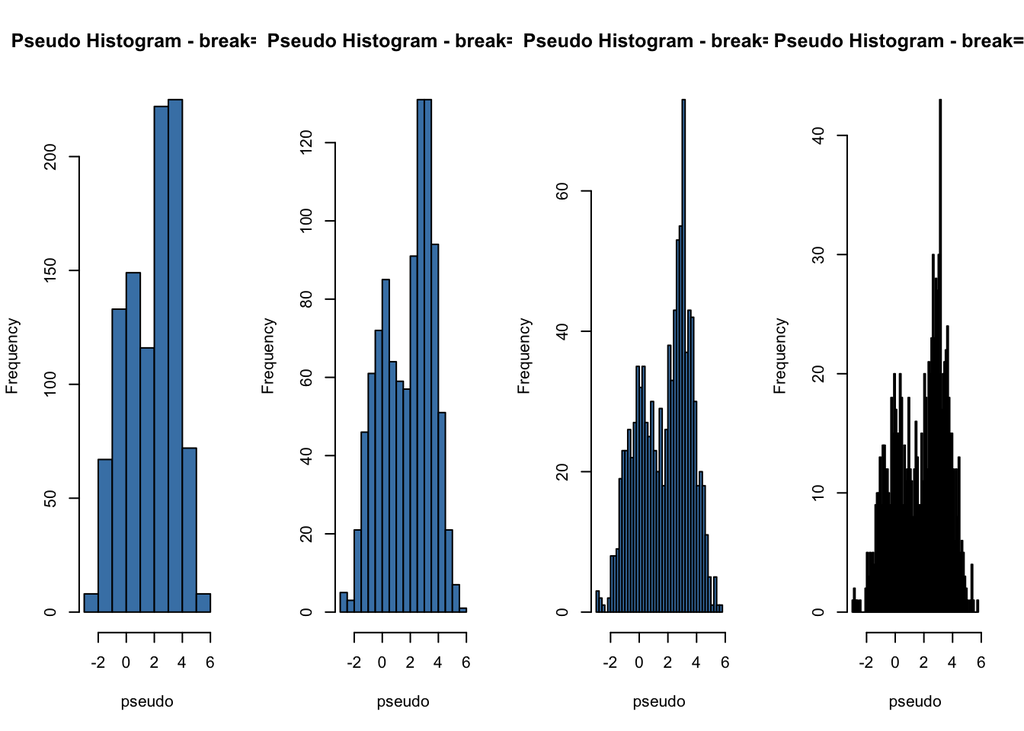

```r
par(mfrow=c(1,4))
hist(pseudo, breaks = 10, main = "Pseudo Histogram - break=10", col = "steelblue")
hist(pseudo, breaks = 30, main = "Pseudo Histogram - break=30",col = "steelblue")
hist(pseudo, breaks = 50, main = "Pseudo Histogram - break=50",col = "steelblue")
hist(pseudo, breaks = 100, main = "Pseudo Histogram - break=100",col = "steelblue")
```

```r
library(fGarch)
```

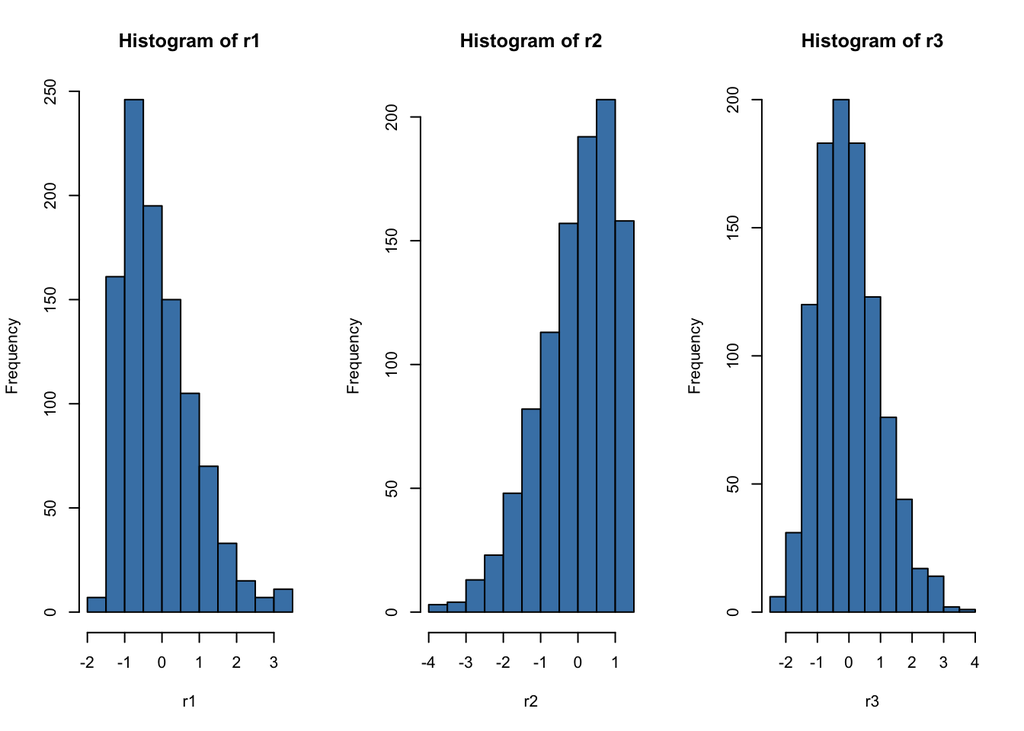

```r
par(mfrow=c(1,3))
set.seed(1234)
r1<-rsnorm(n=1000, xi=2.5)
hist(r1, col="steelblue")
r2<-rsnorm(n=1000, xi=0.1)
hist(r2, col="steelblue")
r3<-rsnorm(n=1000)
hist(r3, col="steelblue")
```

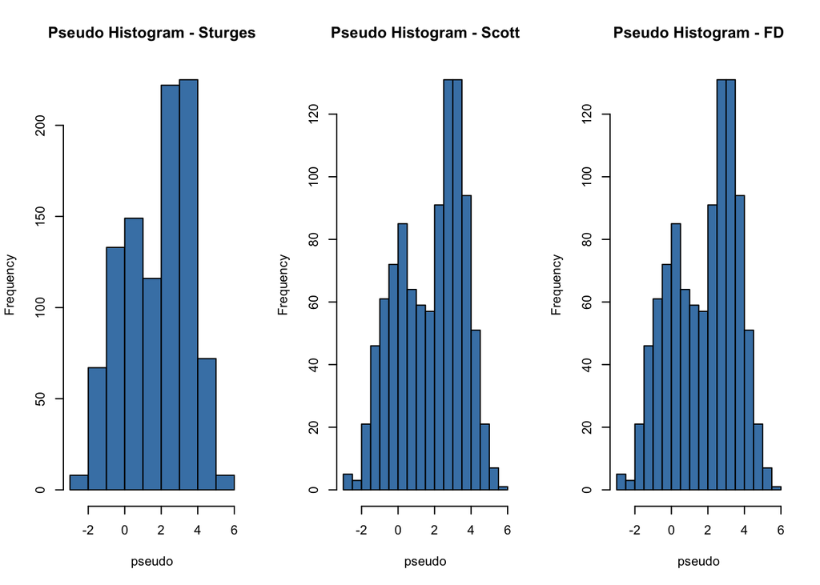

```r
par(mfrow=c(1,3))
hist(pseudo, breaks = "Sturges", main = "Pseudo Histogram - Sturges", col="steelblue")
hist(pseudo, breaks = "Scott", main = "Pseudo Histogram - Scott",col="steelblue")
hist(pseudo, breaks = "FD", main = "Pseudo Histogram - FD",col = "steelblue")
```

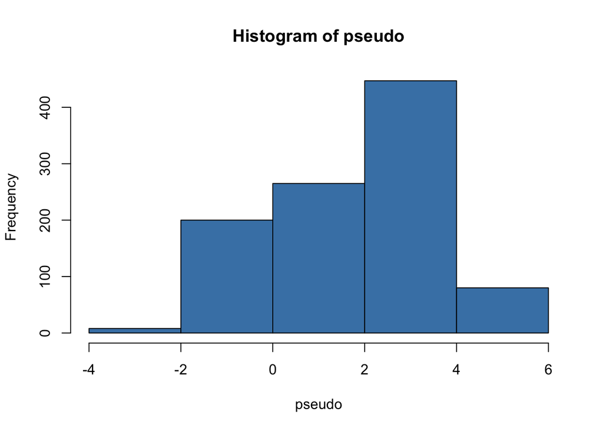

```r
h<-hist(pseudo, col = "steelblue", breaks = 5) # Change the number of breaks
```

**density plots**

Density plots can be thought of as plots of smoothed histograms.

The smoothness is controlled by a bandwidth parameter that is analogous to the histogram binwidth.

Most density plots use a kernel density estimate, but there are other possible strategies; qualitatively the particular strategy rarely matters.

Compute the density data

```r
pseudo.density <- density(pseudo)
pseudo.density
```

```
##
## Call:
##  density.default(x = pseudo)
##
## Data: pseudo (1000 obs.);    Bandwidth 'bw' = 0.4018
##
##        x                y
##  Min.   :-4.136   Min.   :1.506e-05
##  1st Qu.:-1.374   1st Qu.:7.982e-03
##  Median : 1.388   Median :9.127e-02
##  Mean   : 1.388   Mean   :9.043e-02
##  3rd Qu.: 4.149   3rd Qu.:1.462e-01
##  Max.   : 6.911   Max.   :2.525e-01
```

plot density

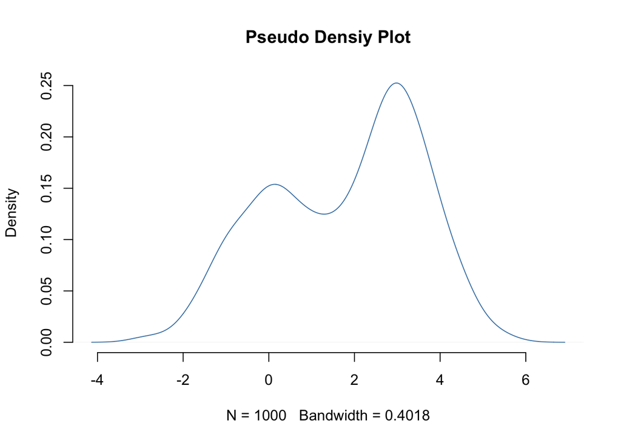

```r
plot(pseudo.density, frame = FALSE, col = "steelblue", main = "Pseudo Densiy Plot")
```

Fill the density plot using `polygon()`

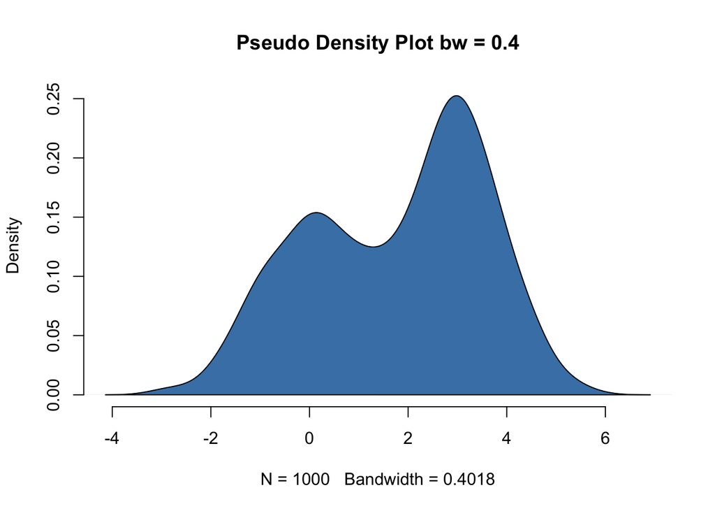

```r
plot(pseudo.density, frame = FALSE, col = "steelblue", main = "Pseudo Density Plot bw = 0.4")
polygon(pseudo.density, col = "steelblue")
```

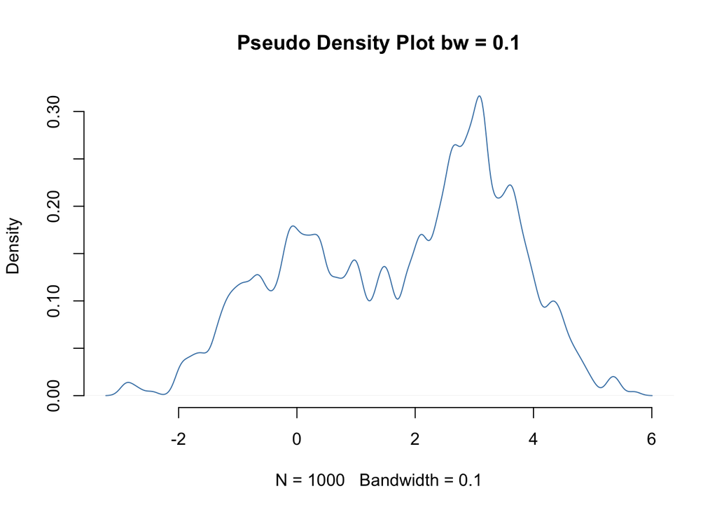

```r
plot(density(pseudo, bw = 0.1), frame = FALSE,col = "steelblue", main = "Pseudo Density Plot bw = 0.1")
```

adding jittered rug

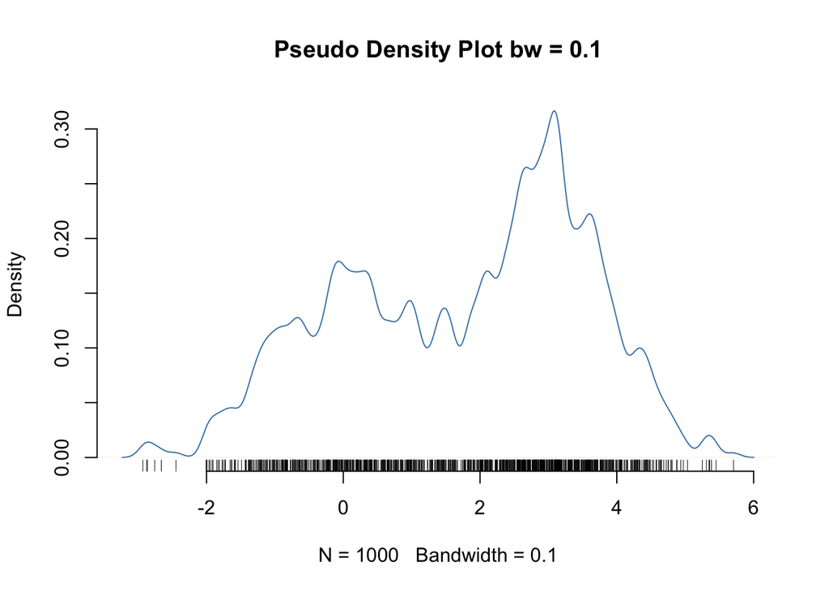

```r
plot(density(pseudo, bw = 0.1), frame = FALSE, col = "steelblue", main = "Pseudo Density Plot bw = 0.1")
rug(jitter(pseudo))
```

# 3 `lattice` package

```r
histogram(x, data, allow.multiple, outer = TRUE, auto.key = FALSE,
          aspect = "fill", panel = lattice.getOption("panel.histogram"),
          prepanel, scales, strip, groups, xlab, xlim, ylab, ylim,
          type = c("percent", "count", "density"),
          nint = if (is.factor(x)) nlevels(x)
          else round(log2(length(x)) + 1),
          endpoints = extend.limits(range(as.numeric(x),
          finite = TRUE), prop = 0.04), breaks, equal.widths = TRUE,
          drop.unused.levels = lattice.getOption("drop.unused.levels"),
          ...,
          lattice.options = NULL, default.scales = list(),
          default.prepanel = lattice.getOption("prepanel.default.histogram"),
          subscripts, subset)
```

```
## Choosing between regular and irregular histogram:
##
## 1.Building regular histogram with maximum number of bins 144.
## - Choosing number of bins via maximum likelihood with BR penalty.
## - Number of bins chosen: 10.
##
##
## 2.Building irregular histogram.
## - Using finest grid based on observations.
## - Choosing number of bins via maximum likelihood with PENB penalty.
## - Using greedy procedure to recursively build a finest partition with at most 100 bins.
## - Pre-selected finest partition with 100 bins.
## - Computing weights for dynamic programming algorithm.
## - Now performing dynamic optimization.
## - Number of bins chosen: 7.
##
##
##
## Regular histogram chosen.
```

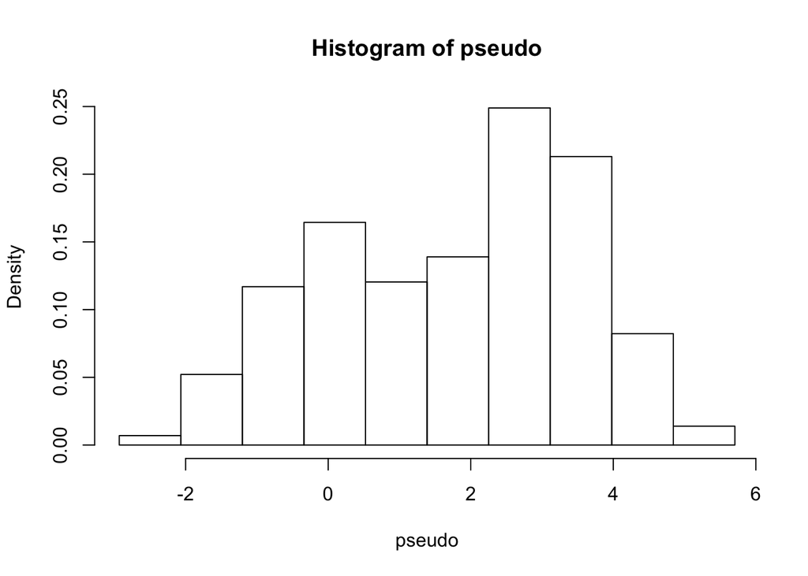

```
## $breaks
##  [1] -2.9304821 -2.0668563 -1.2032306 -0.3396049  0.5240208  1.3876465
##  [7]  2.2512722  3.1148979  3.9785236  4.8421493  5.7057750
##
## $counts
##  [1]   6  45 101 142 104 120 215 184  71  12
##
## $density
##  [1] 0.006947454 0.052105906 0.116948811 0.164423081 0.120422538 0.138949082
##  [7] 0.248950439 0.213055260 0.082211540 0.013894908
##
## $mids
##  [1] -2.49866920 -1.63504349 -0.77141778  0.09220793  0.95583364  1.81945935
##  [7]  2.68308506  3.54671077  4.41033648  5.27396219
##
## $xname
## [1] "pseudo"
##
## $equidist
## [1] TRUE
##
## attr(,"class")
## [1] "histogram"
```

```r
histogram(pseudo)
```

```r
histogram(~ mpg | cyl, data = mtcars)
```

[output not shown]

https://homepage.divms.uiowa.edu/~luke/classes/STAT4580/histdens.html

```r
histogram(~ mpg | cyl,  group = vs, data = mtcars, auto.key = TRUE)
```

[output not shown]

The `densityplot()` function by default adds a jittered strip plot of the data to the bottom

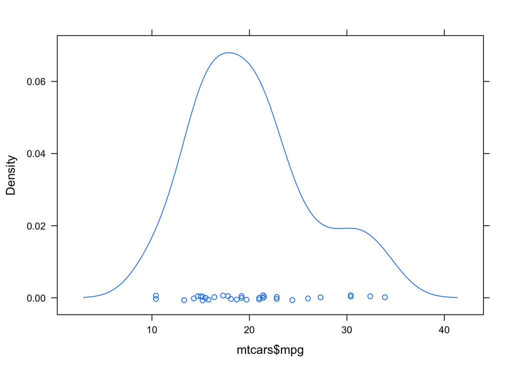

```r
densityplot(mtcars$mpg)
```

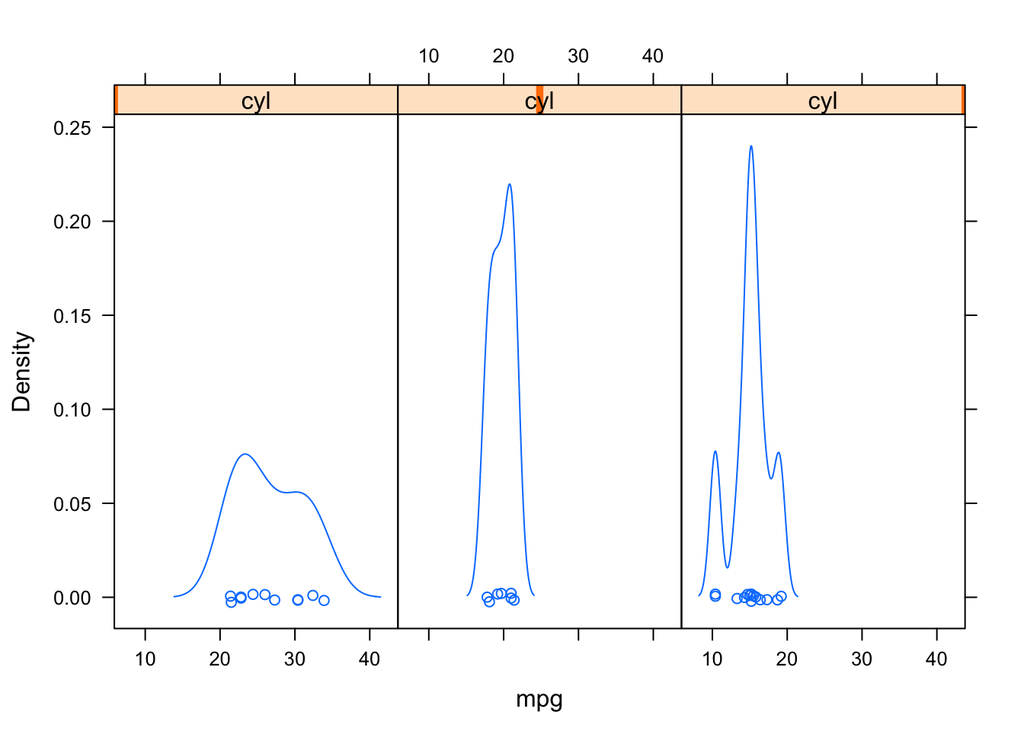

```r
densityplot(~ mpg | cyl, data = mtcars)
```

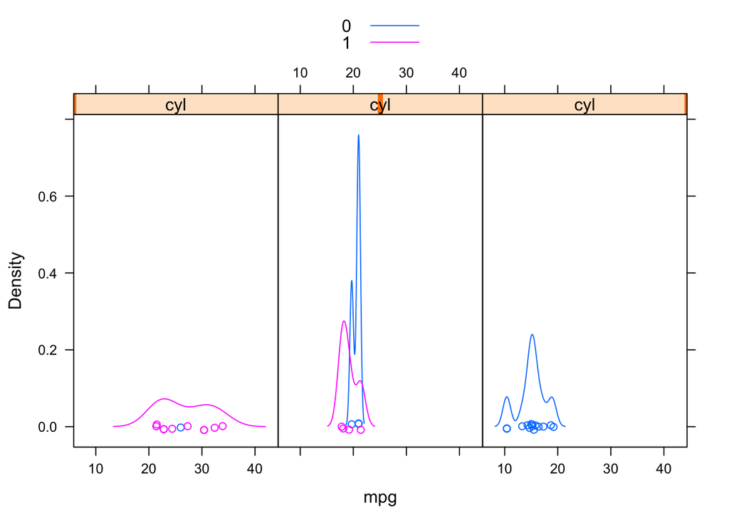

```r
densityplot(~ mpg | cyl, group = vs, data = mtcars, auto.key = TRUE)
```

# 4 `ggplot2` package

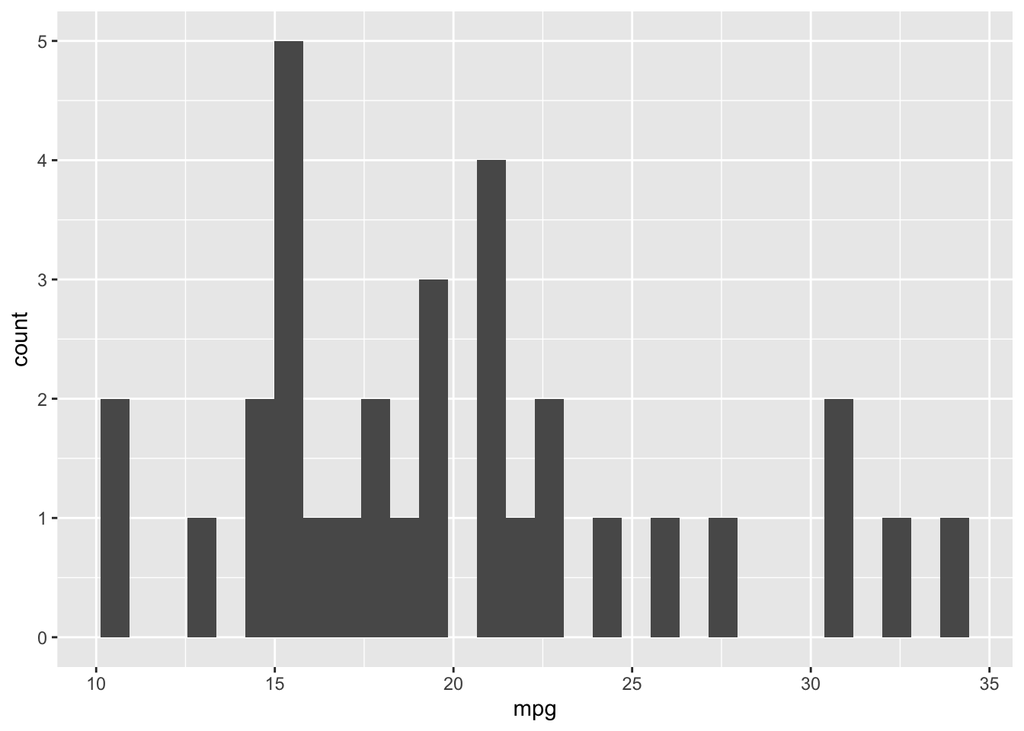

```r
ggplot(mtcars, aes(x = mpg)) + geom_histogram()
```

Change the width of bins

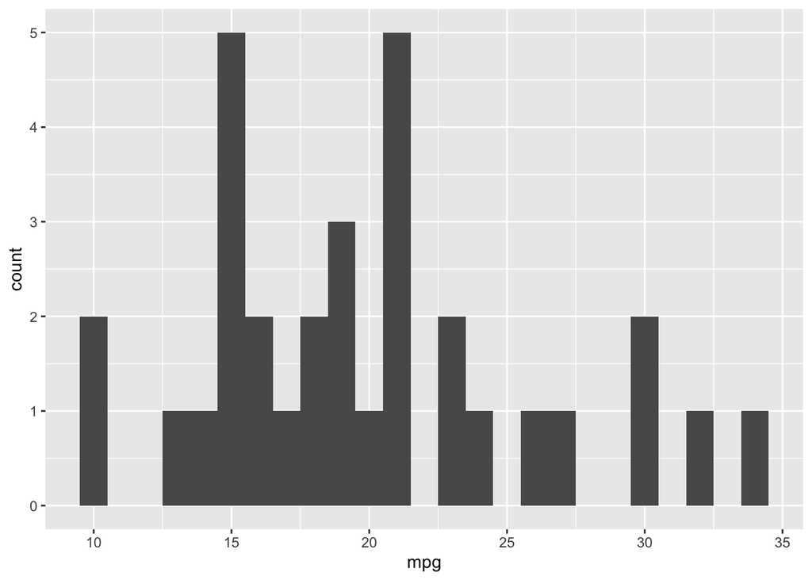

```r
ggplot(mtcars, aes(x = mpg)) + geom_histogram(binwidth = 1)
```

C.3. Change colors

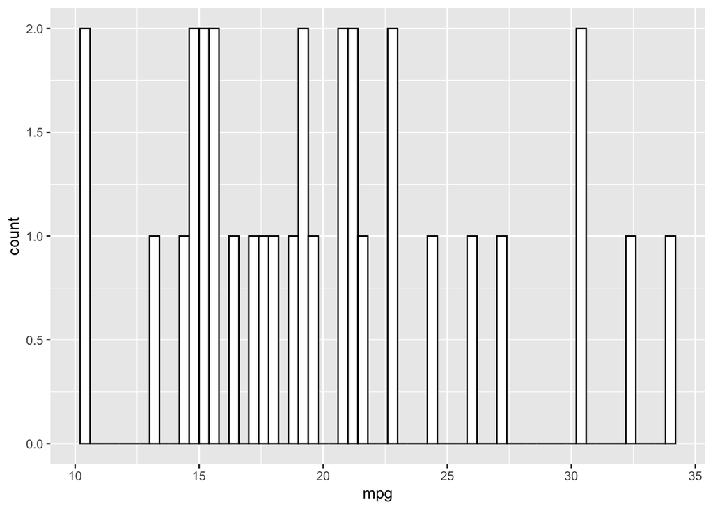

```r
p <- ggplot(mtcars, aes(x = mpg)) + geom_histogram(color="black", fill="white", binwidth = .4)
p
```

C.4. # Add mean line

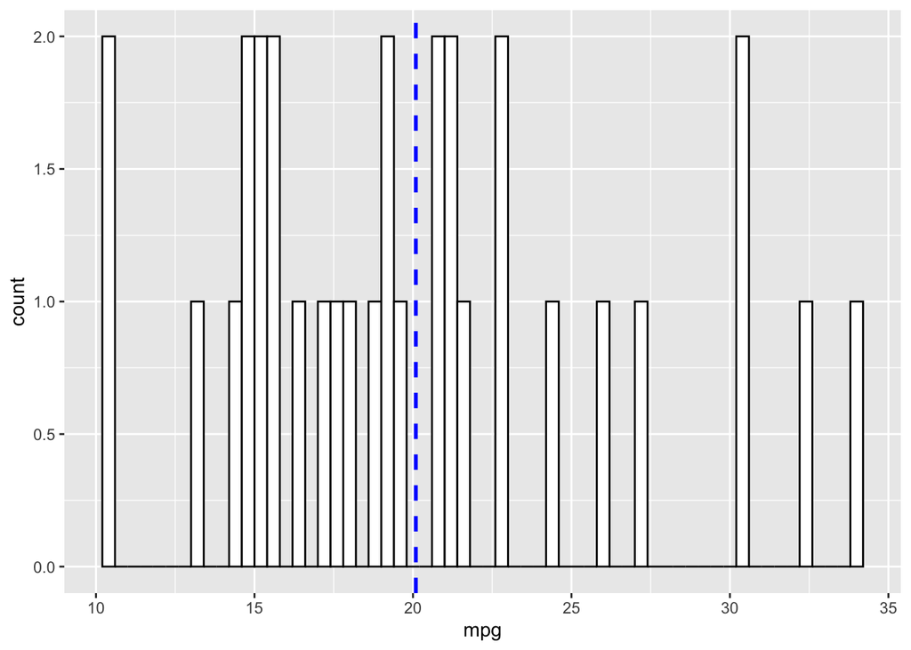

```r
p+ geom_vline(aes(xintercept=mean(mpg)), color="blue", linetype="dashed", size=1, binwidth = 1)
```

# 5 other packages

## 5.1 `MASS` package

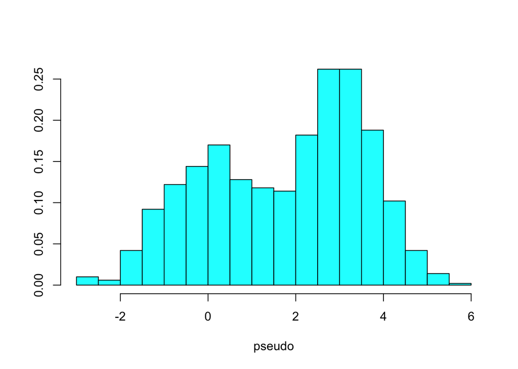

```r
library(MASS)
truehist(pseudo)
```

http://www1.appstate.edu/~arnholta/StatisticsWithR/hist1.pdf

## 5.2 E. **apade package**

E.1.

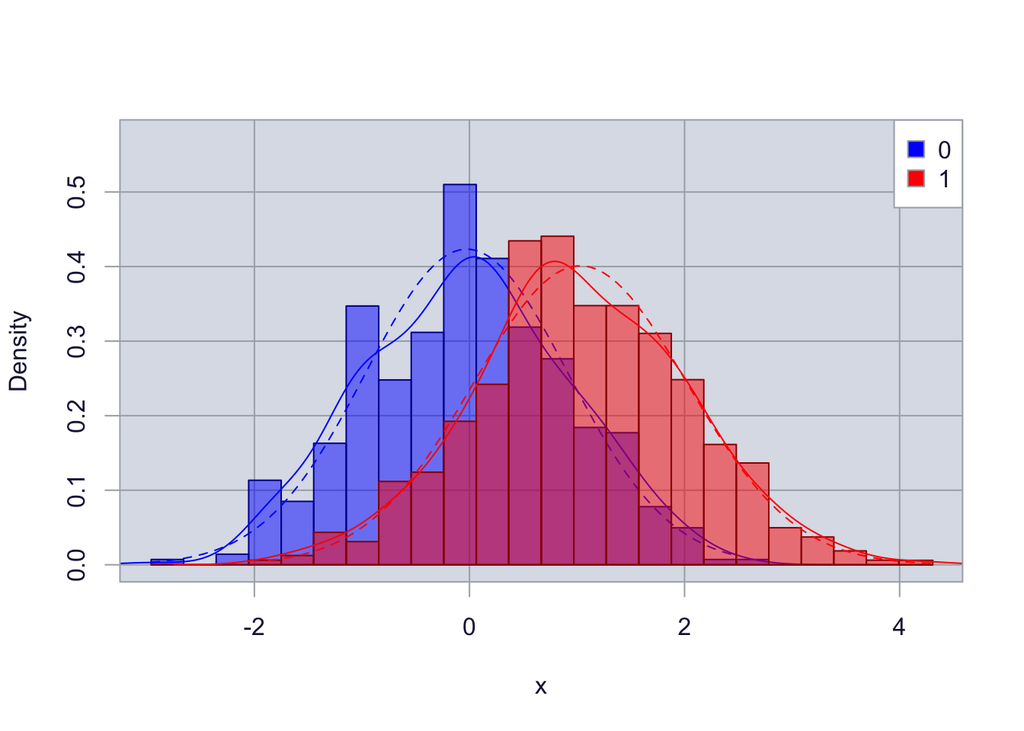

```r
library(epade)
g<-rbinom(1000, 1, 0.5)
x<-rnorm(1000)+g
histogram.ade(x, g, wall=3, breaks=24)
```

## 5.3 F. **LSD package**

F.1.

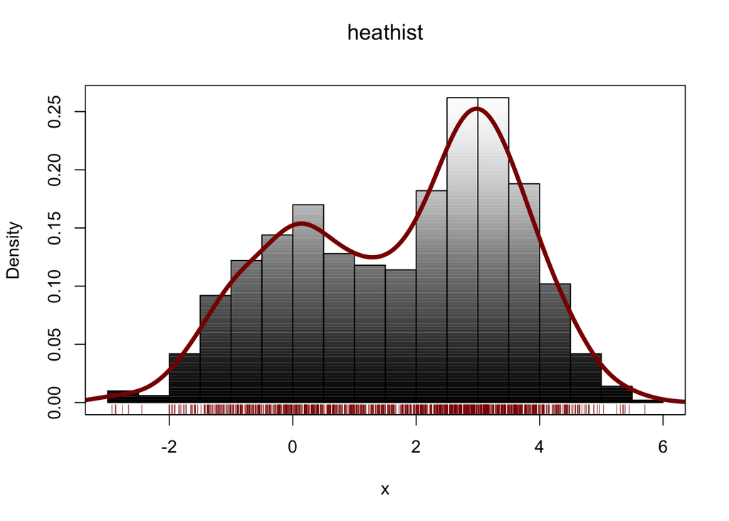

```r
library(LSD)
heathist(pseudo, xlab = "x", add.density = TRUE, col.rug = "darkred")
```

## F. **plotrix package*

F.1.

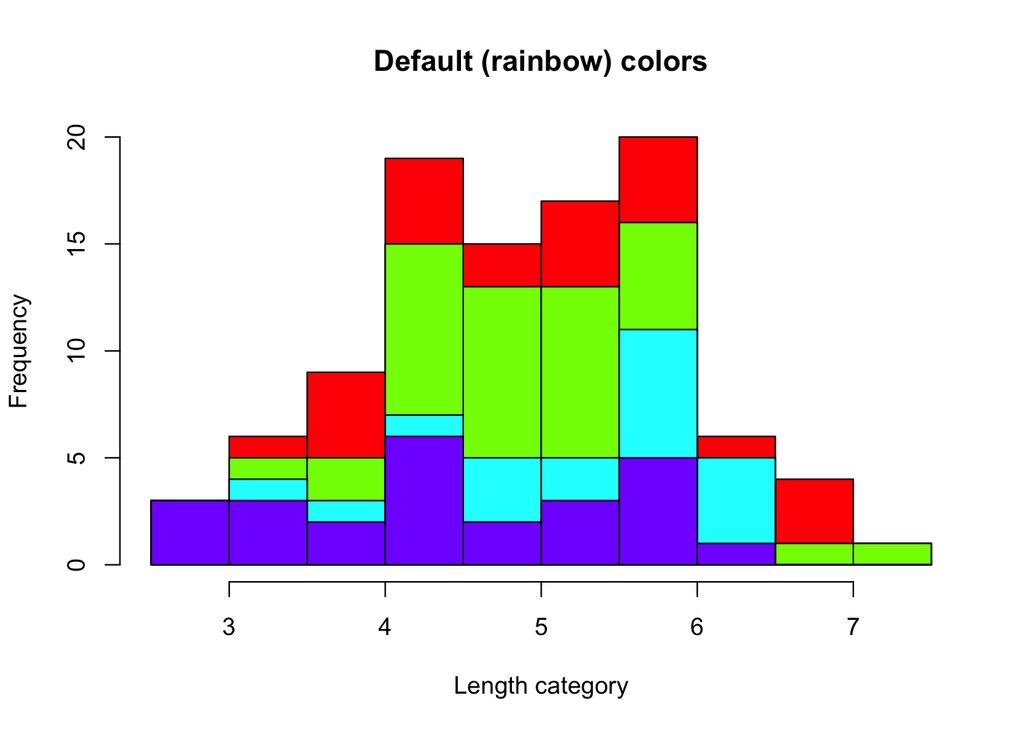

```r
set.seed(409)
df<-data.frame(len = rnorm(100)+5, grp = sample(c("A","B","C","D"), 100, replace = TRUE))
histStack(len ~ grp, data = df, main = "Default (rainbow) colors",
  xlab = "Length category")
```

```r
library(psych)
```

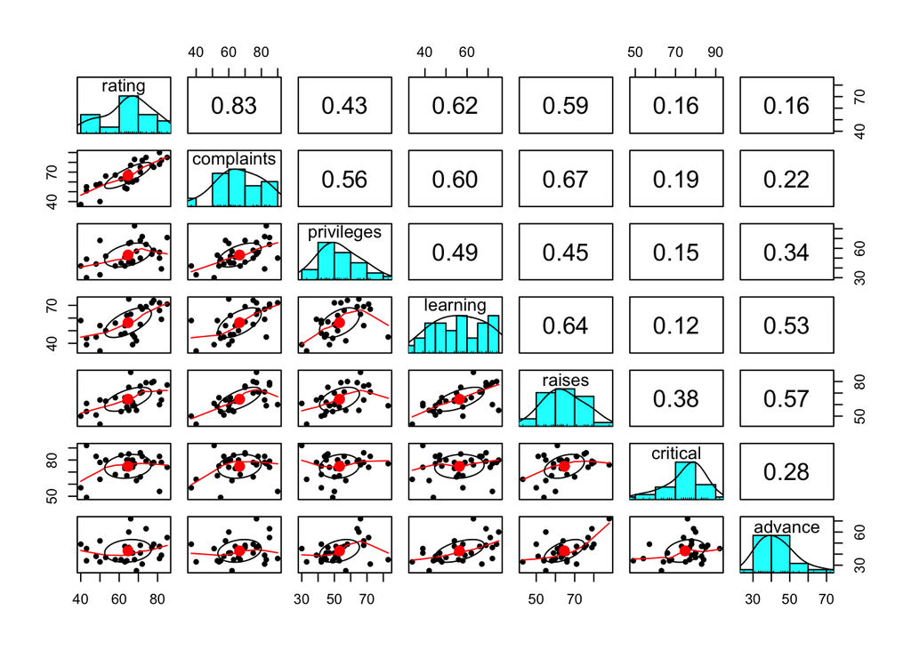

```r
pairs.panels(attitude)   #see the graphics window
```

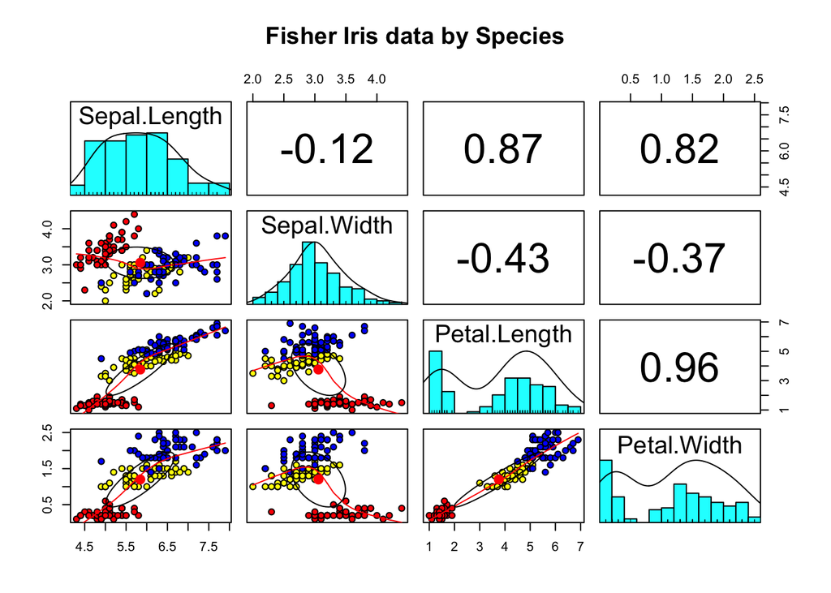

```r
data(iris)
pairs.panels(iris[1:4],bg=c("red","yellow","blue")[iris$Species],
        pch=21,main="Fisher Iris data by Species") #to show color grouping
```

## 5.4 F.2.

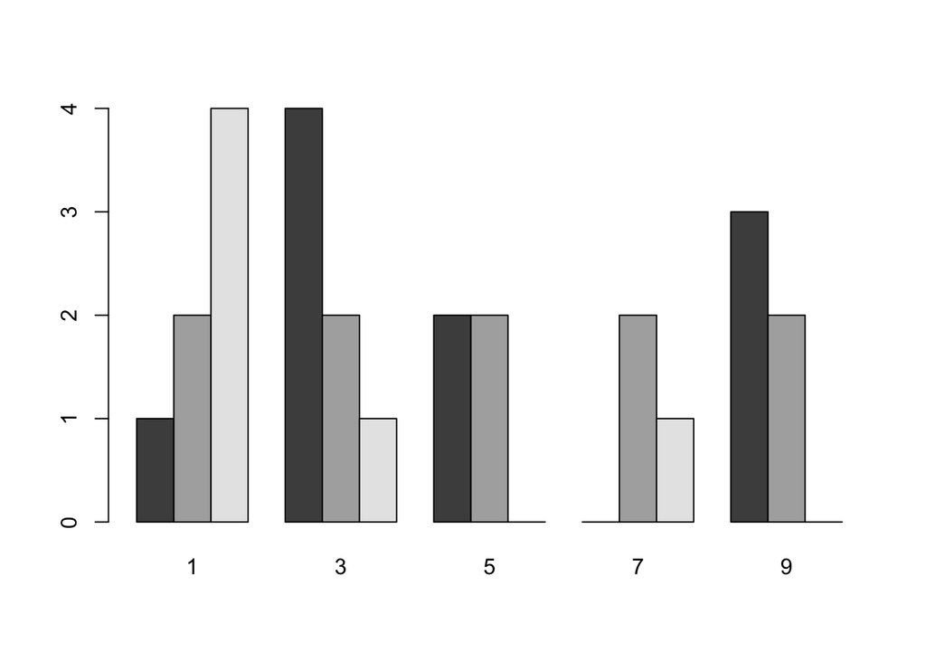

```r
l <- list(runif(10)*10,1:10,c(1,1,1,1,4,8))
 multhist(l)
```

usingR package Interactive Bandwidth Choice

```r
library(UsingR)
source("http://homepage.divms.uiowa.edu/~luke/classes/STAT7400/examples/tkdens.R")
```

```r
tkdens(airquality$Wind, tkrplot=TRUE)
```

[output not shown]

```
## <Tcl>
```

**`WVPlots` packcage**

```r
library(WVPlots)
#DoubleHistogramPlot()
set.seed(34903490)
x = rnorm(50)
y = 0.5*x^2 + 2*x + rnorm(length(x))
frm = data.frame(x=x,y=y,yC=y>=as.numeric(quantile(y,probs=0.8)))
frm$absY <- abs(frm$y)
frm$posY = frm$y > 0
frm$costX = 1
WVPlots::DoubleHistogramPlot(mtcars, "mpeg", "cyl", title="Example double histogram plot")
```

[output not shown]

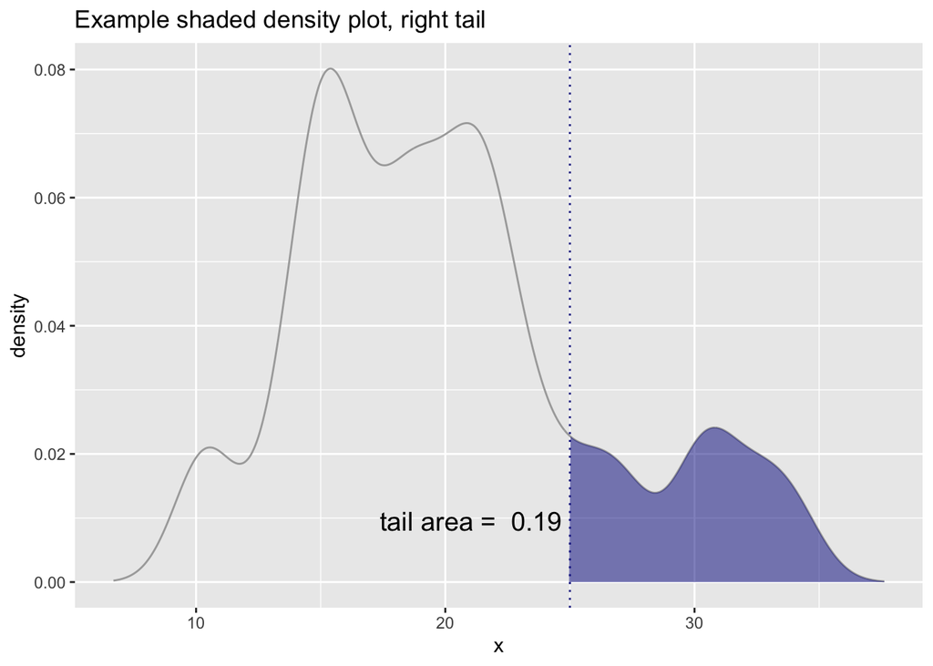

```r
d<-data.frame(x=mtcars$mpg)
threshold = 25
WVPlots::ShadedDensity(d, "x", threshold, tail="right",
                       title="Example shaded density plot, right tail")
```

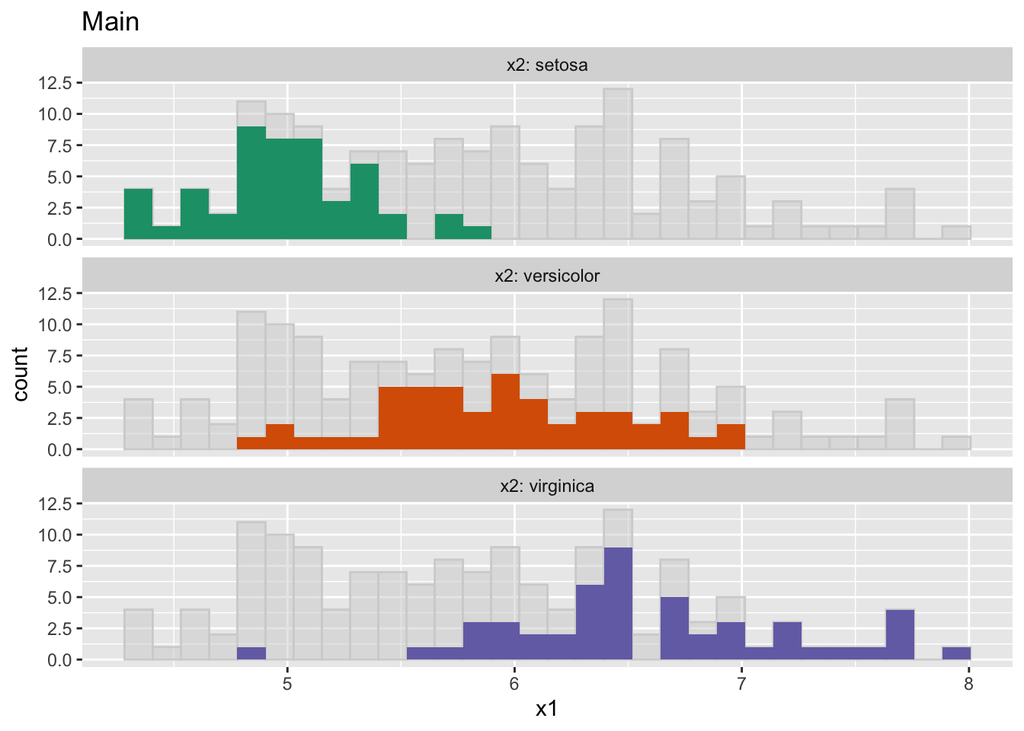

```r
x1<-iris$Sepal.Length
x2<-as.character(iris$Species)
x<-data.frame(x1,x2, stringsAsFactors = FALSE)
ShadowHist(x, "x1","x2",title = "Main") # 3 arguments are not optional!
```

## 5.5 bihistogram